# Team 3 - Lab 4

Hidden Markov Models

Ben Makhlouf, Brian McGreal, Anna Sulc

May 20, 2025

# Data

We chose to work with the PDO variable for the univariate hidden markov model. We worked on a yearly scale and focused on the winter month period to ensure data were aligned on a temporal scale.

For the Stoplight data set, we chose to focus on local biological variables as we thought it may be interesting to see whether all biological data followed the same trends or if there were opposite trends occuring for different parts of the system. We were interested in how this affected models with different states.

# Methods

## Univariate - PDO

We assumed all responses are Gaussian in our models. We chose to fit a simple model with no covariates in both instances and instead and instead focused on the impacts of assuming different numbers of states and exploring model diagnostics and performance.

Here we fit a two state HMM to the annual indices of PDO

```
## #######################
## ## Observation model ##
## #######################
## + winter_pdo ~ norm(mean, sd)
##   * mean.state1 ~ 1
##   * mean.state2 ~ 1
##   * sd.state1 ~ 1
##   * sd.state2 ~ 1
##
## > Estimated observation parameters (t = 1):
##                 state 1 state 2
## winter_pdo.mean  -0.733   0.853
## winter_pdo.sd     0.669   0.502
##
## #########################
## ## State process model ##
## #########################
##         state 1 state 2
## state 1       .      ~1
## state 2      ~1       .
##
## > Estimated transition probabilities (t = 1):
##         state 1 state 2
## state 1   0.832   0.168
## state 2   0.293   0.707
```

```
## $obspar
## , , 1
##
##                    state 1   state 2
## winter_pdo.mean -0.7328287 0.8534060
## winter_pdo.sd    0.6686495 0.5016343
##
##
## $tpm
## , , 1
##
##           state 1   state 2
## state 1 0.8316750 0.1683250
## state 2 0.2928184 0.7071816
```

We fit the model 20 times and explored the likelihood. Plotting the likelihood demonstrated that is was quite stable and remained in a similar range across all 20 iterations. This may be one way to check convergence - if we were located in a local minimum, running a couple hundred iterations might show a likelihod that jumps between two significantly different values.

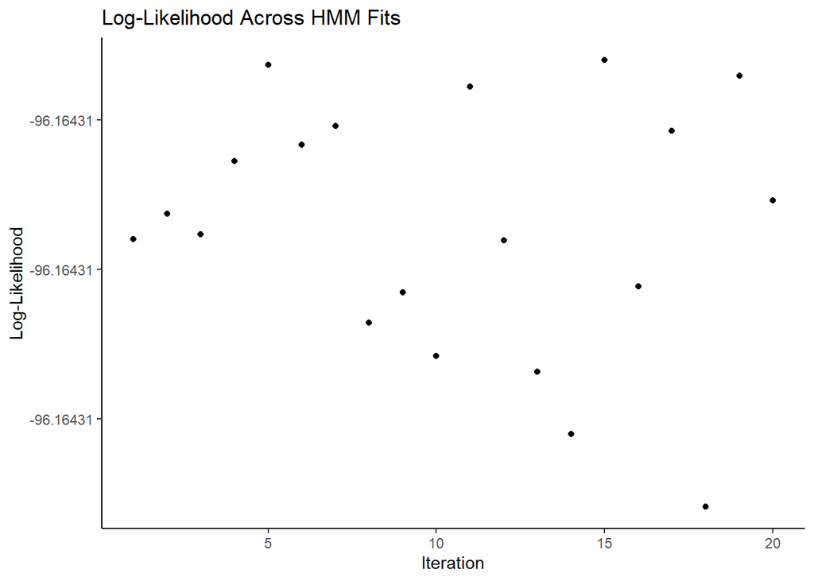

```
## Best model is at iteration 15 with log-likelihood -96.16431
```

**Plot the posterior probability of being in the various states from your best model (e.g. probability of being in state 1 over time)**

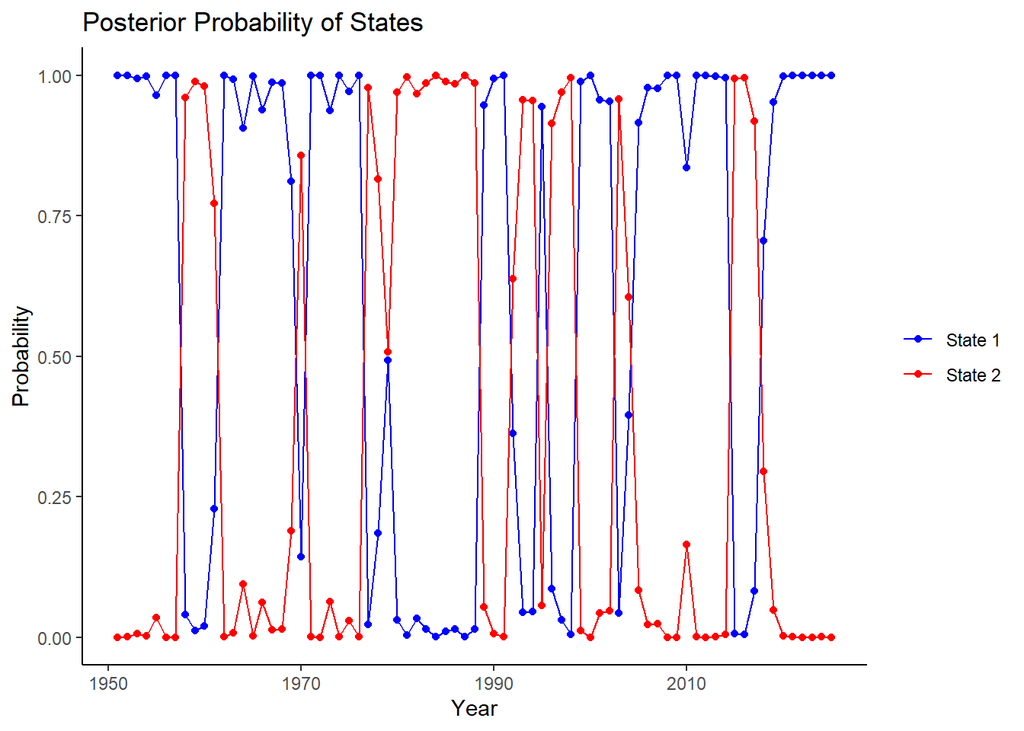

**What is the long-run probability that the PDO is in state 1 versus state 2?**

The long-run probabilities represent the proportion of time the PDO is expected to be in each state over a very long period. This can be calculated using the eigenvalues of the transition matrix. Our results show that we will be in State 1 approximately 2/3s of the time in a long term future.

```
## Long-run probability of being in State 1: 0.6349833
```

```
## Long-run probability of being in State 2: 0.3650167
```

```
## The PDO is predicted to be in State 1 approximately 63.5 % of the time, and in State 2 approximately 36.5 % of the time.
```

**Using slide 15 of the HMM lecture as a template and the matrix in Q3, write out your fitted HMM model as equations.**

Our PDO model has two states and assumes a gaussian distribution

1. Hidden State Process (Markov Chain)

Let $z_t \in \{1, 2\}$ denote the hidden state at time $t$. The hidden states follow a first-order Markov chain:

$$\Pr(z_1 = i) = \pi_i, \quad i \in \{1, 2\}$$

$$\Pr(z_t = j \mid z_{t-1} = i) = a_{ij}, \quad i,j \in \{1, 2\}$$

where $\pi_i$ are the initial state probabilities and $a_{ij}$ are the elements of the transition probability matrix $A$.

2. Observation Model

Let $y_t$ be the observed PDO value at time $t$. Conditional on the hidden state $z_t = k$, the observation is normally distributed:

$$y_t \mid z_t = k \sim \mathcal{N}(\mu_k, \sigma_k^2)$$

for $k \in \{1, 2\}$, where $\mu_k$ and $\sigma_k^2$ are the state-specific mean and variance of the normal distribution.

The transition matrix $A$ for the model:

$$A =
\begin{pmatrix}
0.8316750 & 0.1683250 \\
0.2928184 & 0.7071816
\end{pmatrix}$$

This matrix represents the probabilities of transitioning between two hidden states, **State 1** and **State 2**. In other words:

- From **State 1**, the probability of remaining in **State 1** is $0.8316750$, and the probability of transitioning to **State 2** is $0.1683250$.
- From **State 2**, the probability of transitioning to **State 1** is $0.2928184$, and the probability of remaining in **State 2** is $0.7071816$.

## Multivariate - “Stoplight” Indicator Data

We chose to focus on the eight biological indicators included in the “stoplight” dataset to assess whether there are underlying regimes of survival and mortality for biota being sampled. We begin by reshaping data to suit HMM requirements before proceeding to fit 2-state and 3-state HMMs and compare.

```
## [1] "Reshaped data (first few rows):"
```

```
##   Copepod_richness N_copepod S_copepod Biological_transition
## 1             4.54     -0.76      0.60                   209
## 2            -2.58      0.04     -0.23                   134
## 3            -3.41      0.15     -0.21                    97
## 4            -1.03      0.15     -0.22                    79
## 5            -1.12      0.29     -0.23                   120
## 6             1.99     -0.13      0.09                   156
##   Nearshore_Ichthyoplankton Ichthy_community_index Chinook_salmon_juv
## 1                      0.48                  -9.47               0.09
## 2                      1.64                 -20.44               0.29
## 3                      0.97                 -28.90               0.22
## 4                      1.27                 -14.48               0.12
## 5                      1.95                 -13.98               0.23
## 6                      0.40                  -2.29               0.20
##   Coho_salmon_juv year
## 1            0.08 1998
## 2            0.28 1999
## 3            0.24 2000
## 4            0.44 2001
## 5            0.42 2002
## 6            0.43 2003
```

## 2 state vs. 3 state HMMs

#### 2 states

Here we fit a two state HMM to the set of eight biological indicators

```
## #######################
## ## Observation model ##
## #######################
## + Copepod_richness ~ norm(mean, sd)
##   * mean.state1 ~ 1
##   * mean.state2 ~ 1
##   * sd.state1 ~ 1
##   * sd.state2 ~ 1
##
## + N_copepod ~ norm(mean, sd)
##   * mean.state1 ~ 1
##   * mean.state2 ~ 1
##   * sd.state1 ~ 1
##   * sd.state2 ~ 1
##
## + S_copepod ~ norm(mean, sd)
##   * mean.state1 ~ 1
##   * mean.state2 ~ 1
##   * sd.state1 ~ 1
##   * sd.state2 ~ 1
##
## + Biological_transition ~ norm(mean, sd)
##   * mean.state1 ~ 1
##   * mean.state2 ~ 1
##   * sd.state1 ~ 1
##   * sd.state2 ~ 1
##
## + Nearshore_Ichthyoplankton ~ norm(mean, sd)
##   * mean.state1 ~ 1
##   * mean.state2 ~ 1
##   * sd.state1 ~ 1
##   * sd.state2 ~ 1
##
## + Ichthy_community_index ~ norm(mean, sd)
##   * mean.state1 ~ 1
##   * mean.state2 ~ 1
##   * sd.state1 ~ 1
##   * sd.state2 ~ 1
##
## + Chinook_salmon_juv ~ norm(mean, sd)
```

[output cut: 26 more lines]

```
## Chinook_salmon_juv.sd            0.044   0.076
## Coho_salmon_juv.mean             0.148   0.335
## Coho_salmon_juv.sd               0.092   0.093
##
## #########################
## ## State process model ##
## #########################
##         state 1 state 2
## state 1       .      ~1
## state 2      ~1       .
##
## > Estimated transition probabilities (t = 1):
##         state 1 state 2
## state 1   0.400   0.600
## state 2   0.111   0.889
```

#### 3 states

Here we fit a three state HMM to the set of eight biological indicators

```
## #######################
## ## Observation model ##
## #######################
## + Copepod_richness ~ norm(mean, sd)
##   * mean.state1 ~ 1
##   * mean.state2 ~ 1
##   * mean.state3 ~ 1
##   * sd.state1 ~ 1
##   * sd.state2 ~ 1
##   * sd.state3 ~ 1
##
## + N_copepod ~ norm(mean, sd)
##   * mean.state1 ~ 1
##   * mean.state2 ~ 1
##   * mean.state3 ~ 1
##   * sd.state1 ~ 1
##   * sd.state2 ~ 1
##   * sd.state3 ~ 1
##
## + S_copepod ~ norm(mean, sd)
##   * mean.state1 ~ 1
##   * mean.state2 ~ 1
##   * mean.state3 ~ 1
##   * sd.state1 ~ 1
##   * sd.state2 ~ 1
##   * sd.state3 ~ 1
##
## + Biological_transition ~ norm(mean, sd)
##   * mean.state1 ~ 1
##   * mean.state2 ~ 1
##   * mean.state3 ~ 1
##   * sd.state1 ~ 1
##   * sd.state2 ~ 1
##   * sd.state3 ~ 1
##
## + Nearshore_Ichthyoplankton ~ norm(mean, sd)
##   * mean.state1 ~ 1
##   * mean.state2 ~ 1
##   * mean.state3 ~ 1
##   * sd.state1 ~ 1
```

[output cut: 44 more lines]

```
## Coho_salmon_juv.sd               0.092   0.093   0.123
##
## #########################
## ## State process model ##
## #########################
##         state 1 state 2 state 3
## state 1       .      ~1      ~1
## state 2      ~1       .      ~1
## state 3      ~1      ~1       .
##
## > Estimated transition probabilities (t = 1):
##         state 1 state 2 state 3
## state 1   0.400   0.600     0.0
## state 2   0.111   0.889     0.0
## state 3   0.050   0.050     0.9
```

# Results

We tested two forms of models. In a first step we experimented with the PDO data and a two state model that assumed a normal response of the data.

The following section summarizes the outputs of our analysis.

### Transition Probabilities

Transition probabilities for the PDO model are fairly evenly distributed, with perhaps a slight tendency towards the first state.

```
##         state 1.1 state 2.1
## state 1 0.8316750 0.1683250
## state 2 0.2928184 0.7071816
```

Transition probabilities for the 2-state biological indicator model are skewed heavily in favor of the system existing in the second state.

```
## , , 1
##
##           state 1   state 2
## state 1 0.4000002 0.5999998
## state 2 0.1111108 0.8888892
```

Transition probabilities for the 3-state biological indicator model are perplexing. The model identifies the same probabilites of movement between state 1 and state 2 as the two state model. This is made possible because the model leaves virtually no room for movement from either of these states into state 3. If the system were to find itself in state 3 this model estimated transitioning away from it would be difficult but not impossible, and once this occured the system would be very unlikely to return to that state.

```
## , , 1
##
##            state 1    state 2      state 3
## state 1 0.40000145 0.59999855 1.032210e-25
## state 2 0.11111150 0.88888850 1.492772e-09
## state 3 0.05001449 0.05004858 8.999369e-01
```

### States

In the case of the PDO model, we seem to be in the first state more than the second. This is consistent with the estimates of long term probabilities where we spend 2/3s of the time in one state and 1/3 in the other.

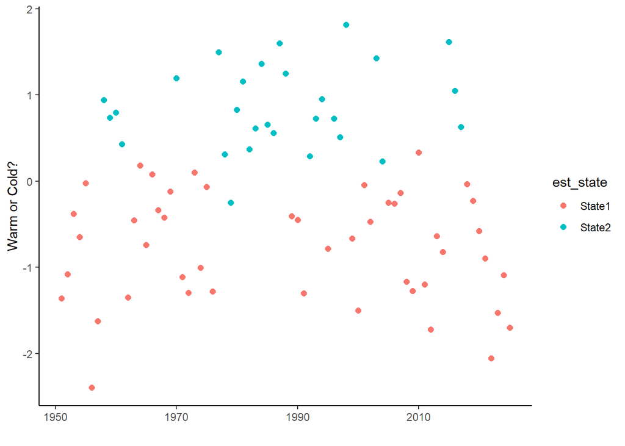

The results from the two state biological indicators model is consistent with the transition matrix indicating a strong tendency towards state 2.

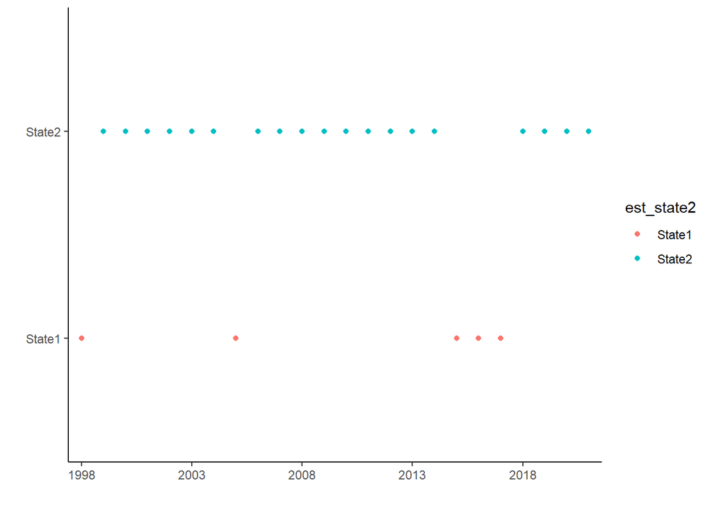

Results from the three state biological indicators model mirror those from the two state model. This is consistent with the transition matrix leaving very little chance for the model to move into a third state.

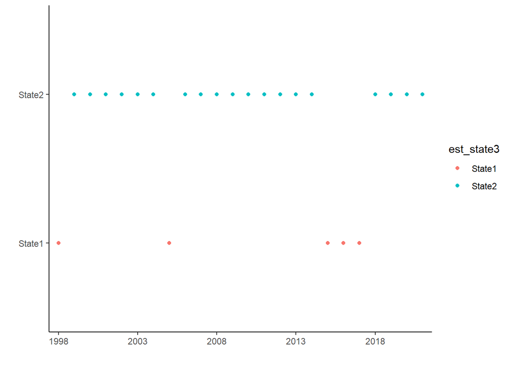

# Discussion

## PDO HMM

As a first experience with HMMs, this lab was a great way to appreciate their strengths and also inquire about potential limitations. We used the PDO example to explore the diagnostics and performance of a HMM. The results demonstrated a 60/30 split in states (for long term probabilities, individual model runs could vary between 50/50 and 80/20 for example) which for PDO seemed intuitive given it is an oscillating even but remains uneven in duration and in its phases.

While the model performed well and our 20 iteration “check” using the loglikelihood seemed to show a stable global minimum, the remainder of diagnostics raised the question of convergence of HMMs. It seemed that while it is easy to compare the performance of different HMMs and their fit, checking convergence is less direct. The loglikelihood test is effective however a question may be raised for how many iterations are sufficient before one decides the model has converged. We explored the TMB object of the fitted model but it was unclear whether other diagnostics were available beyond those listed on the slides.

## Multistate Biological Data HMM

Modeling multistate biological data with HMMs revealed interesting results. A two state modeling approach heavily favored the second state but allowed movement between the two. The addition of a third state however made no difference in the model’s estimation of regime, with the third state being basically ignored by the model. This is perhaps evidence that, based on the biological indicators sampled, the system moves between one of two states (perhaps healthy and unhealthy).

# Team contributions

All team members worked through each lab sections and reconvened to discuss results and the general direction of the lab. Based on this discussion, we then collectively combined our code and each contributed to the write up.